# ME323 - Introdução aos Modelos Probabilísticos

## Distribuições de probabilidade conjunta

## Vetores aleatórios

Vimos até agora distribuições de probabilidade referentes a uma única variável aleatória.

Entretanto, é comum termos interesse em analisar probabilidades de duas ou mais variáveis aleatórias simultaneamente.

Ex: lançar uma moeda 3 vezes. Seja \(X_i\) a v.a. indicando o resultado do \(i\)-ésimo lançamento (\(X_i=1\), se cara e \(X_i=0\), se coroa). Então o resultado do experimento é representado pelo **vetor aleatório**: \[\mathbf{X}=(X_1,X_2,X_3)\]

## Duas variáveis aleatórias discretas

Sejam \(X\) e \(Y\) duas v.a. discretas definidas no espaço amostral \(\Omega\) de um experimento e \(\mathbf{X}=(X,Y)\) o vetor aleatório. A **função de probabilidade conjunta** \(p(\mathbf{x})\) é definida para cada par de números \(\mathbf{x}=(x,y)\) por:

\[p(\mathbf{x})=p(x,y)=P(X=x, Y=y)\] Temos que \(p(\mathbf{x})\geq0\) e \(\sum_x\sum_yp(x,y)=1\).

Agora, seja \(A\) qualquer conjunto particular que consista em pares de valores \(\mathbf{x}\). Então: \[P[\mathbf{X}\in A]=\sum_{\mathbf{x}\in A}p(\mathbf{x})\]

Ex: \(A=\{(x,y): x+y=5\}\) ou \(A=\{(x,y): \max(x,y)\leq 3\}\).

## Exemplo

Ao adquirir um seguro residencial ou para carro, a pessoa deve escolher o valor da franquia. Uma empresa oferece os seguintes valores de franquia para carro: \(\$100\), \(\$250\). Para residência: \(\$0\), \(\$100\), \(\$200\). Considere selecionar ao acaso um cliente com essas duas apólices na empresa.

\(X\): franquia do carro \(Y\): franquia da residência. Temos a seguinte tabela de probabilidade conjunta:

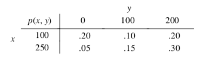

\(P(X=100,Y=0)=0.2\), \(P(X=250,Y=200)=0.30\).

## Exemplo

\(X\): franquia do carro \(Y\): franquia da residência. Temos a seguinte tabela de probabilidade conjunta:

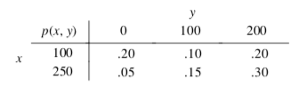

\(P(Y\geq 100) = P(X=100,Y=100)\) \(+P(X=250,Y=100)+P(X=100,Y=200)\) \(+ P(X=250,Y=200)=0.75\)

\(P(X=100) = P(X=100,Y=0)+P(X=100,Y=100)\) \(+P(X=100,Y=200)=0.50\)

## Distribuição Marginal

A **função massa de probabilidade marginal de \(X\)**, denotada por \(p_X(x)\) é dada por:

\[p_X(x)=\sum_{y:p(x,y)>0}p(x,y)\] A **função massa de probabilidade marginal de \(Y\)**, denotada por \(p_Y(y)\) é dada por:

\[p_Y(y)=\sum_{x:p(x,y)>0}p(x,y)\]

## Duas variáveis contínuas

A probabilidade de que o valor observado de uma v.a. contínua \(X\) fique no conjunto unidimensional \(A\) (um intervalo, por exemplo) é obtida ao integrar a f.d.p. \(f_X(x)\) sobre o conjunto \(A\).

A probabilidade de que o par \((X,Y)\) das v.a. contínuas caiam em um conjunto bidimensional \(A\) (um retângulo, por exemplo) é obtida ao integrar a chamada **função da densidade conjunta**.

## Função de densidade de probabilidade conjunta

Sejam \(X\) e \(Y\) v.a. contínuas. Uma f.d.p. conjunta \(f_{X,Y}(x,y)\) para essas duas v.a.’s deve satisfazer:

\[f_{X,Y}(x,y)\geq0\]

\[\int_{-\infty}^{\infty}\int_{-\infty}^{\infty}f_{X,Y}(x,y)dxdy=1\]

Em particular, caso \(A\) seja o retângulo bidimensional \(\{(x,y): a\leq x\leq b,\, c<y\leq d\}\), então

\[P[(X,Y)\in A]=P(a\leq X\leq b,\,c\leq Y\leq d)=\int_a^b\int_c^df_{X,Y}(x,y)dydx\]

## Função de densidade de probabilidade conjunta

\[P[(X,Y)\in A]=P(a\leq X\leq b,\,c\leq Y\leq d)=\int_a^b\int_c^df_{X,Y}(x,y)dydx\]

é o volume sob a superfície de densidade, considerando a região \(A\).

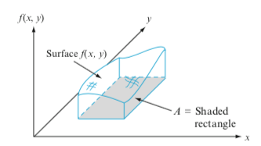

## Distribuição Marginal

As **funções densidade de probabilidade marginal** de \(X\) e \(Y\), denotadas por \(f_X(x)\) e \(f_Y(y)\), são dadas por:

\[f_X(x)=\int_{-\infty}^{\infty}f_{X,Y}(x,y)dy\,,\quad -\infty<x<\infty\] \[f_Y(y)=\int_{-\infty}^{\infty}f_{X,Y}(x,y)dx\,,\quad -\infty<y<\infty\]

## Variáveis aleatórias independentes

Duas v.a. \(X\) e \(Y\) são **independentes** se, para cada par de valores \(x\) e \(y\):

- se \(X\) e \(Y\) são discretas:

\[P(X=x,Y=y)=P(X=x)P(Y=y)\]

- se \(X\) e \(Y\) são contínuas:

\[f_{X,Y}(x,y)=f_X(x)f_Y(y)\]

## Mais de duas v.a.’s

Se \(X_1,X_2,\ldots,X_n\) são v.a.’s discretas, a função de massa de probabilidade conjunta é:

\[P(X_1=x_1,X_2=x_2,\ldots,X_n=x_n)\]

Se as v.a.’s são contínuas, a f.d.p. conjunta é \(f_{X_1,X_2,\ldots,X_n}(x_1,x_2,\ldots,x_n)\) de forma que para qualquer intervalo \([a_1,b_1],\ldots,[a_n,b_n]\):

\[P(a_1\leq X_1\leq b_1,\ldots,a_n\leq X_n\leq b_n)=\int_{a_1}^{b_1}\ldots\int_{a_n}^{b_n}f_{X_1,X_2,\ldots,X_n}(x_1,x_2,\ldots,x_n)dx_n\ldots dx_1\]

## Independência

As v.a.’s \(X_1,X_2,\ldots,X_n\) são ditas **independentes** se para cada subconjunto \(X_{i_1},X_{i_2},\ldots,X_{i_k}\) das variáveis (cada par, cada trip, etc…) a f.m.p. ou f.d.p. conjuntas do subconjunto for igual ao produto das f.d.p. ou f.m.p. marginais.

## Distribuições condicionais

Sejam \(X\) e \(Y\) duas v.a. contínuas com f.d.p. conjunta \(f_{X,Y}(x,y)\) e f.d.p. marginal de \(X\) \(f_X(x)\). Então, para qualquer valor \(X\) de \(x\) para o qual \(f_X(x)>0\), a **função densidade de probabilidade condicional de \(Y\) dado que \(X=x\)** é:

\[f_{Y\mid X}(y\mid x)=\frac{f_{X,Y}(x,y)}{f_X(x)}\quad -\infty < y < \infty\]

Se \(X\) e \(Y\) forem discretas, substituir as f.d.p. por f.m.p. nesta definição fornecerá a **função massa de probabilidade condicional de \(Y\) quando \(X=x\)**.

## Exemplo - Vetor Aleatório

Cada cliente em uma loja deve escolher apenas entre 3 formas de pagamento disponíveis: dinheiro, crédito ou débito. Consideremos o experimento aleatório observar a escolha do cliente na forma de pagamento. Assumiremos que os experimentos são independentes.

Sejam \(p_1\), \(p_2\) e \(p_3\) as probabilidades do cliente escolher dinheiro, crédito e débito, respectivamente.

Dentre 10 clientes que chegaram na loja e efetuaram uma compra, qual a probabilidade de que os 5 primeiros paguem com dinheiro, os 3 seguintes com crédito e os 2 últimos com débito?

Resultado experimental igual a: \(1111122233\), com probabilidade:

> \(p_1^5\times p_2^3\times p_3^2\)

## Exemplo

Resultado experimental igual a: \(2223311111\), com probabilidade:

> \(p_1^5\times p_2^3\times p_3^2\)

Resultado experimental igual a: \(1122311123\), com probabilidade:

> \(p_1^5\times p_2^3\times p_3^2\)

Temos muitas combinações possíveis, que resultam em 5 pagando em dinheiro, 3 com crédito e 2 com débito.

## Exemplo

Seja \(X_i\) o total de clientes que escolhem a forma de pagamento \(i\).

Se quisermos saber a probabilidade de que exatamente 5 clientes paguem com dinheiro, 3 paguem com crédito e 2 com débito, precisamos somar todas as probabilidades das combinações que resultem nesse total de clientes em cada categoria, que são \(\binom{10}{5}\binom{5}{3}\binom{2}{2} =2520\) combinações.

\[P(X_1=5,X_2=3,X_3=2) = \frac{10!}{5!3!2!}p_1^5p_2^3p_3^2\]

## Distribuição Multinomial

É uma generalização do experimento de Bernoulli, podendo ter resultados possíveis em uma dentre \(r\) categorias.

**Modelo Multinomial**

1. O resultado de cada experimento pode ser classificado em uma de \(r\) respostas.
2. A probabilidade da experimento assumir o valor \(i\) é \(p_{i}\), \(i=1, 2, \ldots,r\), com \[\sum_{i=1}^{r}p_{i}=1\]
3. As observações são independentes.

## Distribuição Multinomial

Considere repetições de \(n\) experimentos independentes e idênticos. Cada experimento pode resultar em uma dentre \(r\) categorias de resultados possíveis.

Denotaremos por \(X_i\) o total de experimentos que resultaram na categoria \(i\). Denotamos por \(p_i\) a probabilidade de um experimento resultar na categoria \(i\).

\(\mathbf{X}=(X_1,X_2,\ldots,X_r)\sim Multinomial (n,p_1,p_2,\ldots,p_r)\) tem distribuição de probabilidade dada por:

\[P(X_1=n_1, X_2=n_2, \ldots , X_r=n_r)=\frac{n!}{n_1! \ldots n_r!}p_1^{n_1}p_2^{n_2} \ldots p_r^{n_r}\]

em que \(\displaystyle \sum_{i=1}^{r}n_{i}=n\) e com \(\displaystyle \sum_{i=1}^{r}p_{i}=1\).

Note que \(r=2\), a distribuição Multinomial se reduz à Binomial.

## Distribuição Multinomial

Ex: urna com 3 bolas vermelhas, 4 bolas brancas e 5 bolas azuis.

Retiramos 3 bolas da urna, anotamos a cor sorteada, mas a bola é devolvida à urna depois de cada retirada (sorteio com reposição).

Seja \(\mathbf{X}=(X_1,X_2,X_3)\) o vetor aleatório representando o número de bolas vermelhas, brancas e azuis sorteadas, respectivamente.

Então \(\mathbf{X}\sim Multinomial(3,3/12,4/12,5/12)\).

Qual a probabilidade de obter 3 bolas azuis?

\[P(X_1=0,X_2=0,X_3=3)=(5/12)^3\]

## Distribuição Multinomial

Se designarmos a componente \(n_1\) como “sucesso” e juntarmos as demais numa mesma que designamos “fracasso”, a variável aleatória \(n_1\) é o número de sucessos em \(n\) ensaios de Bernoulli, ou seja, \(n_1 \sim Bin(n,p_1)\).

Portanto: \(\qquad \mathbb E(n_1)=np_1 \qquad\) e \(\qquad Var(n_1)=np_1(1-p_1)\).

Analogamente aplicando o mesmo argumento a cada \(n_i\) temos: \[\mathbb E(n_i)=np_i \qquad \mbox{e} \qquad Var(n_i)=np_i(1-p_i)\]

## Esperança Condicional

Vimos que os valores observados de uma v.a. \(X\) podem mudar consideravelmente a distribuição de uma outra v.a. \(Y\), isto é, a distribuição de \(Y\mid X=x\) pode ser diferente da distribuição de \(Y\). Obs: casos em que \(X\) e \(Y\) são independentes, esta mudança não ocorre.

Além de conhecer a distribuição de \(Y\mid X=x\), devemos conhecer também sua esperança.

- Caso discreto: Sejam \(X\) e \(Y\) v.a.’s discretas e seja \(x\) um número ral tal que \(p_X(x)>0\).

\[\psi(x)=E(Y\mid X=x) = \sum_y yp_{Y\mid X}(y\mid x)\] Note que \(\psi(.)\) é uma função da v.a. \(X\), portanto temos a v.a.:

\[\psi(X)=E(Y\mid X)\]

## Esperança Condicional

Exemplo: Suponha uma sequência de \(n\) ensaios de Bernoulli independentes com probabilidades de sucesso \(p\)

- Sejam X e Y os números de sucessos e fracassos, respectivamente
- A distribuição de massa conjunta é:

\[p_{X,Y}(k,n-k)=\binom{n}{k}p^k(1-p)^{n-k}\,, k=0,1,\ldots,n\]

Para cada \(k=0,1,2,\ldots,n\):

\[p_{Y\mid X}(l\mid k)=\begin{cases} 1\quad\mbox{se } l=n-k\\ 0\quad\mbox{caso contrário} \end{cases}\]

\[ \psi(k)=E(Y\mid X=k)=n-k\]

Portanto:

\[E(Y\mid X)=n-X\]

## Esperança Condicional

- Caso contínuo: Sejam \(X\) e \(Y\) v.a.’s contínuas e seja \(x\) um número real tal que \(f_X(x)>0\). A esperança condicional de \(Y\) dados \(X=x\) e dada por:

\[\psi(x)=E(Y\mid X=x)=\int_{-\infty}^{\infty}yf_{Y\mid X}(y\mid x)dy\] Assim, como no caso discreto, \(\psi(.)\) é uma função da v.a. X, portanto é também uma v.a.:

\[\psi(X) = E(Y \mid X)\]

## Exemplo - Normal Bivariada

Seja \((X,Y)\) um vetor aleatório que segue a distribuição normal bivariada:

\[f_{X,Y}(x,y)=\frac{1}{2\pi \sqrt{1-\rho^2}}\exp\left[-\frac{(x^2-2\rho xy+y^2)}{2(1-\rho^2)}\right]\] em que \(\rho\in (-1,1)\).

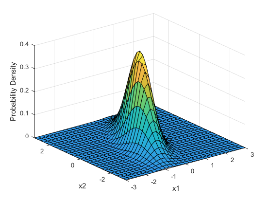

## Exemplo - Normal Bivariada

As marginais de \(X\) e \(Y\) são normais (confira!).

\[f_{Y\mid X}(y\mid x)=\frac{f_{X,Y}(x,y)}{f_X(x)}\quad -\infty < y < \infty\]

\[f_{Y\mid X}(y\mid x) = \frac{1}{\sqrt{2\pi(1-\rho^2)}}\exp\left[ -\frac{(y-\rho x)^2}{1(1-\rho^2)}\right]\] \[Y\mid X=x\sim N(\rho x, (1-\rho^2))\]

\[\psi(x)=E(Y\mid X=x)=\rho x\]

\[\psi(X)=E(Y\mid X)=\rho X\]

Veja que à medida que a correlação \(\rho\) aumenta, as variáveis \(X\) e \(E(Y\mid X)\) se aproximam.

## Propriedades

Sejam \(X\) e \(Y\) v.a.’s e \(g\) uma função real contínua. Então:

\[E(Y)=E[E(Y\mid X)]\]

\[E[Y g(X)]=E[E(Y\mid X)g(X)]\]

- Se \(X\) é uma v.a. discreta:

\[E(Y)=\sum_x E(Y\mid X=x)P(X=x)\]

- Se \(X\) é uma v.a. contínua:

\[E(Y)=\int_{-\infty}^{\infty}E(Y\mid X=x)f_X(x)dx\]

## Variância Condicional

A medida de incerteza acerca da variável \(X\) para um valor específico (ou conhecido) de \(Y\) é chamada **variância condicional**, denotada por \(V(X|Y=y)\). Ela é definida por:

\[ \begin{aligned} V(X|Y=y) & = E([X-E(X|Y=y)]^2|Y=y) \\ & = E(X^2|Y=y) - E^2(X|Y=y) \end{aligned} \]

As principais propriedades da Variância Condicional são:

\[ \begin{aligned} V(X) & = E[V(X|Y)] + V[E(X|Y)] \\ V[E(X|Y)] & \leq V(X) \end{aligned} \]

## Exemplo - Variância Condicional

A densidade conjunta de \(X\) e \(Y\) é: \[ f(x,y) = \frac{e^{-x/y}e^{-y}}{y}, 0 < x < \infty, 0<y<\infty\]

Encontrem \(E(X|Y)\), \(E(X)\), \(V(X|Y)\) e \(V(X)\).

**Solução**:

1. Encontre \(f_{X|Y}(x|y)\)
2. Encontre \(E(X|Y)\)
3. Encontre \(V(X|Y)\)
4. Encontre \(E(X)\)
5. Encontre \(V(X)\)

## Exemplo - Esperança e Variância Condicionais

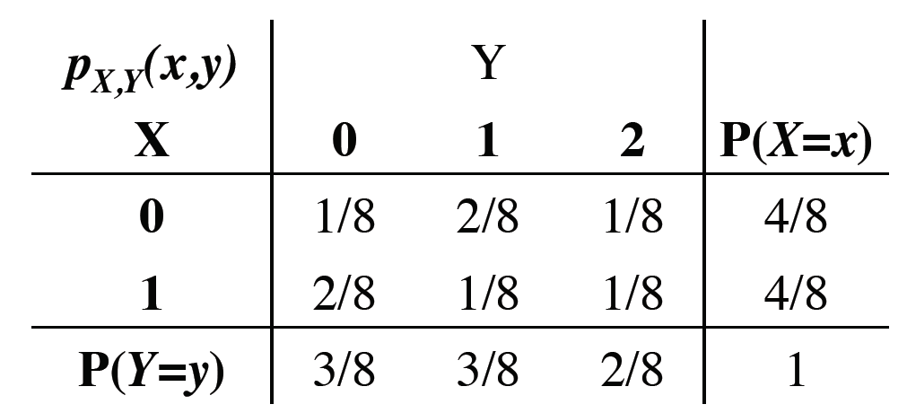

Encontrem:

- Distribuição condicional de \(Y|X\);
- \(E(Y|X=x)\) e a sua distribuição;
- \(E(Y)\) pela distribuição marginal e pela condicional;
- \(V(Y|X=x)\) e sua distribuição;
- \(V(Y)\) diretamente e condicionando em \(X\).

## Leituras

- Devore: capítulo 5.
- Magalhães: capítulo 5.

Slides produzidos pelos professores:

- Samara Kiihl
- Tatiana Benaglia
- Benilton Carvalho